# data_exploration_project

Sella

2/21/2022

## R Markdown

For this project containing real world messy data, I am to search whether some factors affect the school popularity and people’s preferences. Moreover, Google trends has been the indicator for comparing data of a certain time range, representing the popularity of how it is being searched. In this case, the google trend data represent the amount of school popularity.

The very first step is compiling all the trends of the schools

```r
library(tidyverse)
```

```r
library(purrr)
library(dplyr)
library(readr)
library(jtools)

list <- list.files(path = "raw_data", pattern = "trends_up_to", full.names = TRUE)


trends <- list %>%
  map(read_csv) %>%
  bind_rows()
```

Next, I noticed that there are couple of datas that has the same school name. Therefore, we need to filter so that we have only 1 school per school name

```r
id_name <- read_csv("raw_data/id_name_link.csv") %>%
  group_by(schname) %>%
  mutate(N=n()) %>%
  filter(N==1)
```

```r
structural_date = as.Date("2015-01-01")
trends <- trends %>%
  na.omit(trends) %>%
  mutate(new_date = as.Date(monthorweek)) %>%
  group_by(keyword) %>%
  mutate(new_index = (index-mean(index))/sd(index))

b2015_trend <- trends %>%
  group_by(schname) %>%
  filter(new_date<structural_date) %>%
  mutate(average_index_2015before = mean(new_index)) %>%
  distinct(schname, .keep_all= TRUE)

a2015_trend <- trends %>%
  group_by(schname) %>%
  filter(new_date>=structural_date) %>%
  mutate(average_index_2015later = mean(new_index)) %>%
  distinct(schname, .keep_all= TRUE)

a2015_trend <- a2015_trend[c("schname", "average_index_2015later")]
b2015_trend <- b2015_trend[c("schname", "average_index_2015before")]

b2015_trend <- b2015_trend %>%
  left_join(a2015_trend, by = "schname", keep = TRUE) %>%
  left_join(id_name, by = c("schname.x" = "schname"), keep = TRUE) %>%
  na.omit()
```

Cohort files contains the detailed informations regarding to predominant degree, SAT scores, Debt, reported earnings and search Index

```r
cohorts<- read_csv("raw_data/Most+Recent+Cohorts+(Scorecard+Elements).csv")
cohorts <- cohorts %>%
  right_join(b2015_trend, by = c("UNITID" = "unitid"), keep = TRUE)

cohorts<- filter(cohorts, PREDDEG == 3)

earnings <- rank(cohorts$`md_earn_wne_p10-REPORTED-EARNINGS`)/nrow(cohorts)
```

I personally think that variables that affects how a school is known are earnings (in 10 years range), SAT score on average, graduates average debt and the number of enrolled students in the school. Amount of earnings has been a good indicator of a good school as people would think that being a school graduate would have a potential of being accepted in high earning paying jobs.SAT score has been known as something that indicates the quality of how the students perform well in their studies and top universities has been known to have high SAT score on average. Schools with high debts would not be a good school as it has the chance of go bankrupt and close their institution. In this way, I considered school debt as a negative correlation toward school popularity.

```r
cohorts <- cbind(cohorts, earnings)
cohorts <- cohorts[grep("[[:digit:]]", cohorts$UGDS), ]
cohorts <- cohorts[grep("[[:digit:]]", cohorts$SAT_AVG), ]
cohorts <- cohorts[grep("[[:digit:]]", cohorts$GRAD_DEBT_MDN_SUPP), ]
cohorts <- cohorts[grep("[[:digit:]]", cohorts$PCTPELL), ]

cohorts <- cohorts %>%
  mutate(UGDS_new = as.numeric(UGDS)) %>%
  mutate(SAT_AVG_new = as.numeric(SAT_AVG)) %>%
  mutate(GRAD_DEBT_MDN_SUPP_new = as.numeric(GRAD_DEBT_MDN_SUPP))


reg1<- lm(average_index_2015before ~ earnings + UGDS_new + SAT_AVG_new + GRAD_DEBT_MDN_SUPP_new, data= cohorts)
reg2<- lm(average_index_2015before ~ earnings + UGDS_new +SAT_AVG_new + GRAD_DEBT_MDN_SUPP_new, data= cohorts)


summary(reg1)
```

```
##
## Call:
## lm(formula = average_index_2015before ~ earnings + UGDS_new +
##     SAT_AVG_new + GRAD_DEBT_MDN_SUPP_new, data = cohorts)
##
## Residuals:
##      Min       1Q   Median       3Q      Max
## -0.44594 -0.07412 -0.00008  0.07269  0.52568
##
## Coefficients:
##                          Estimate Std. Error t value Pr(>|t|)
## (Intercept)             1.141e-01  3.953e-02   2.886 0.003971 **
## earnings                5.688e-02  1.632e-02   3.486 0.000507 ***
## UGDS_new                2.956e-06  4.702e-07   6.286 4.47e-10 ***
## SAT_AVG_new            -6.765e-05  3.143e-05  -2.152 0.031568 *
## GRAD_DEBT_MDN_SUPP_new  8.838e-07  7.886e-07   1.121 0.262657
## ---
## Signif. codes:  0 '***' 0.001 '**' 0.01 '*' 0.05 '.' 0.1 ' ' 1
##
## Residual standard error: 0.1152 on 1283 degrees of freedom
## Multiple R-squared:  0.0439, Adjusted R-squared:  0.04092
## F-statistic: 14.73 on 4 and 1283 DF,  p-value: 9.073e-12
```

```r
summary(reg2)
```

```
##
## Call:
## lm(formula = average_index_2015before ~ earnings + UGDS_new +
##     SAT_AVG_new + GRAD_DEBT_MDN_SUPP_new, data = cohorts)
##
## Residuals:
##      Min       1Q   Median       3Q      Max
## -0.44594 -0.07412 -0.00008  0.07269  0.52568
##
## Coefficients:
##                          Estimate Std. Error t value Pr(>|t|)
## (Intercept)             1.141e-01  3.953e-02   2.886 0.003971 **
## earnings                5.688e-02  1.632e-02   3.486 0.000507 ***
## UGDS_new                2.956e-06  4.702e-07   6.286 4.47e-10 ***
## SAT_AVG_new            -6.765e-05  3.143e-05  -2.152 0.031568 *
## GRAD_DEBT_MDN_SUPP_new  8.838e-07  7.886e-07   1.121 0.262657
## ---
## Signif. codes:  0 '***' 0.001 '**' 0.01 '*' 0.05 '.' 0.1 ' ' 1
##
## Residual standard error: 0.1152 on 1283 degrees of freedom
## Multiple R-squared:  0.0439, Adjusted R-squared:  0.04092
## F-statistic: 14.73 on 4 and 1283 DF,  p-value: 9.073e-12
```

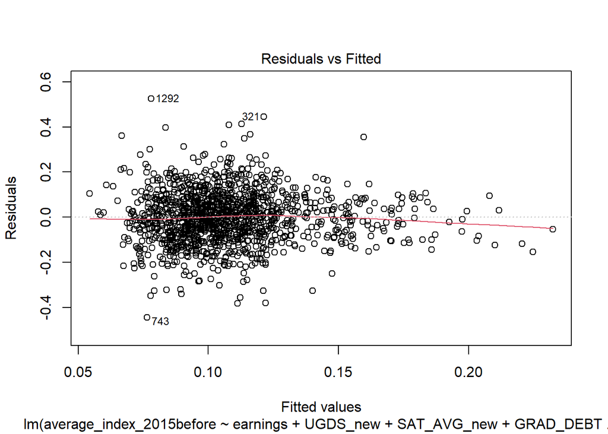

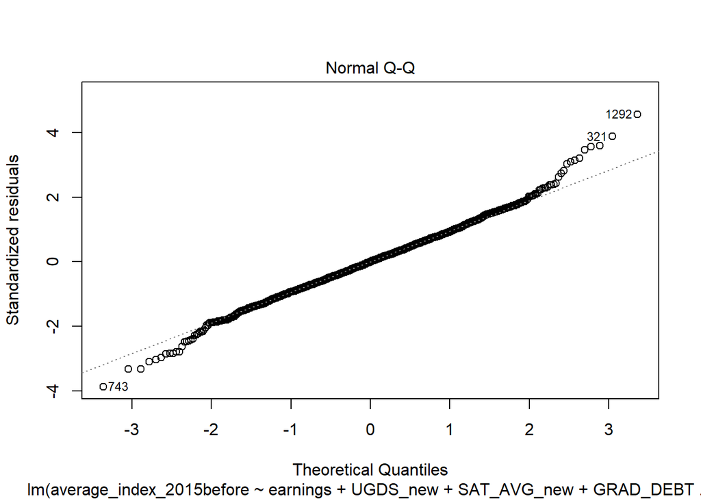

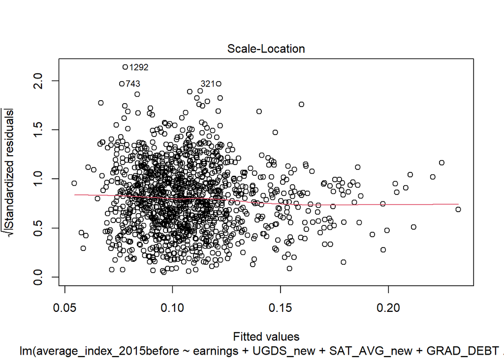

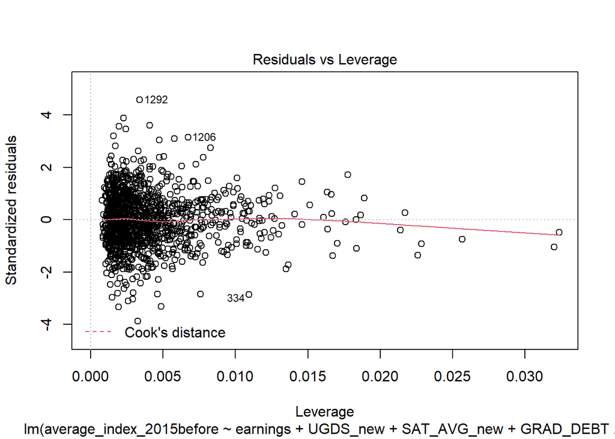

```r
plot(reg1)
```

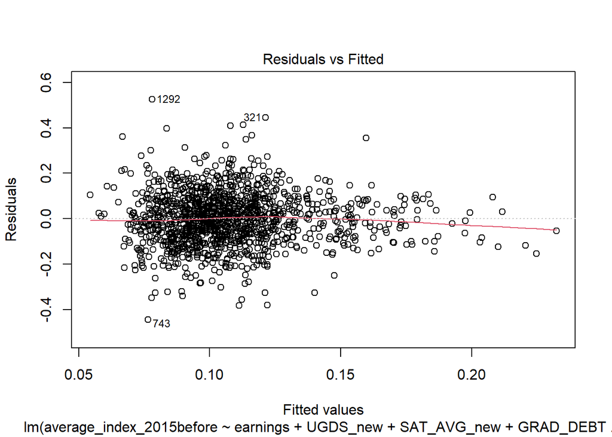

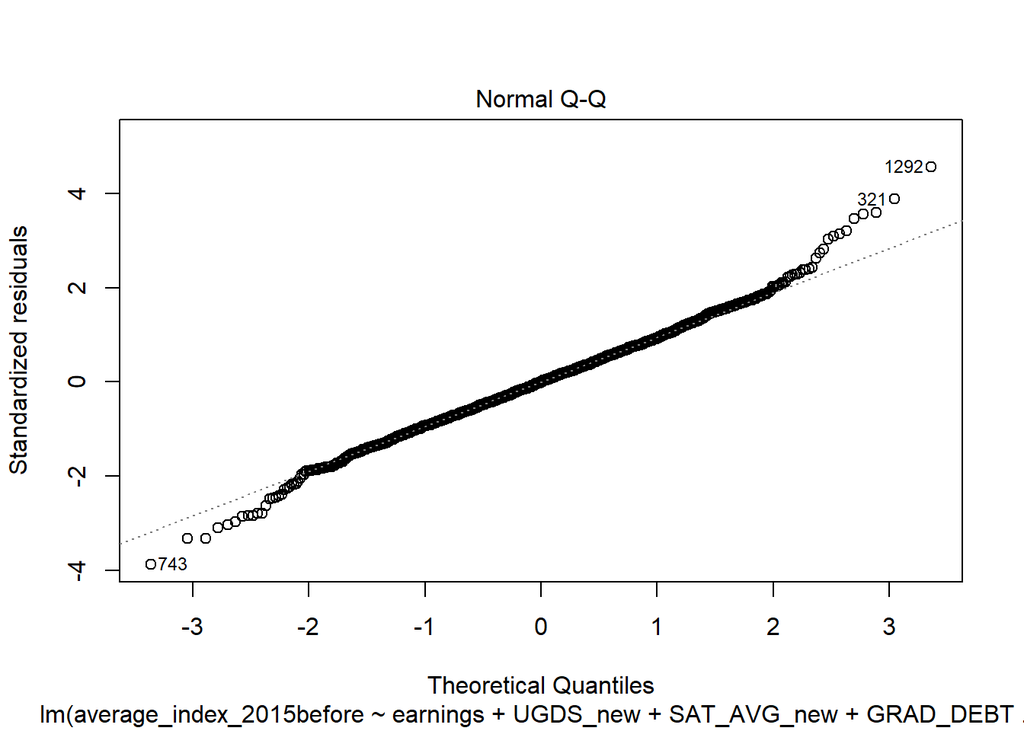

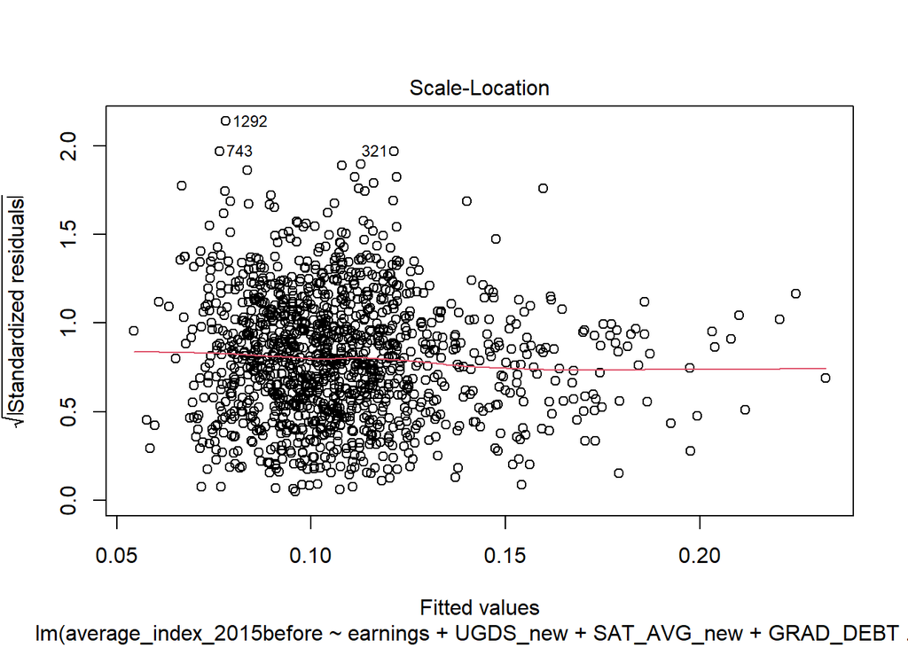

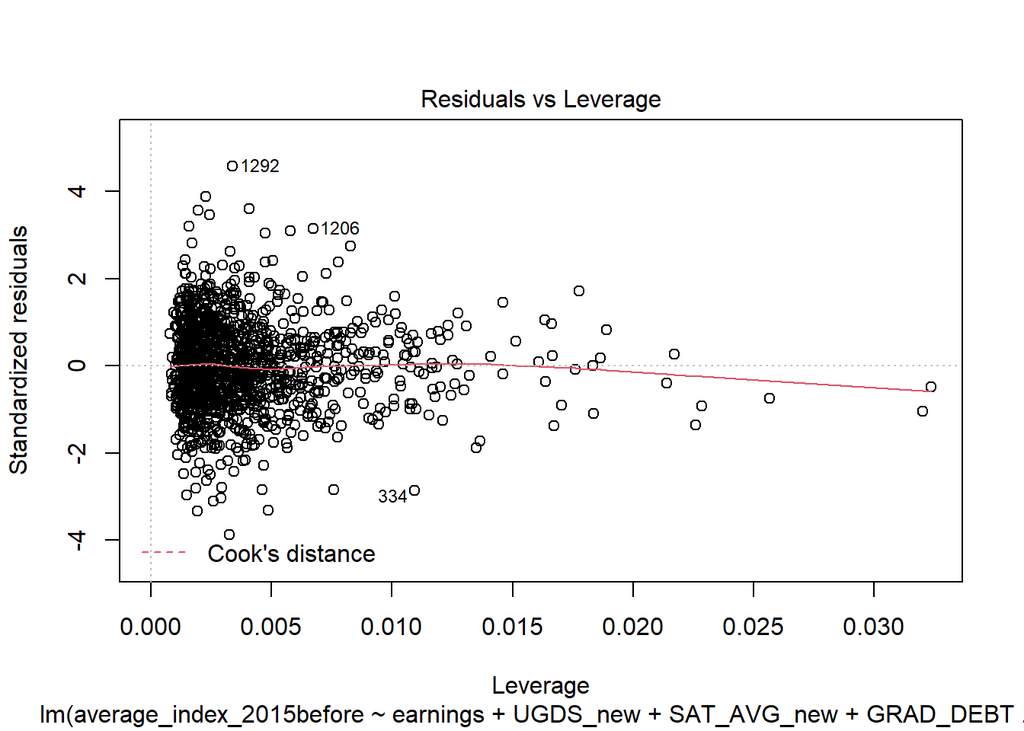

```r
plot(reg2)
```